# Ejercicios no lineales

Osmar Dominique Santana Reyes

2025-10-16

1. La data sustancia contiene la cantidad de una sustancia (Y en porcentaje) en muestras de un producto en función del numero de semanas (X) desde que se produjo. Se sabe que se puede ajustar a un modelo exponencial de la forma:

$$Y = \beta_0 + (\alpha - \beta_0)
e^{-\beta_1(X - \delta)}$$
a) ¿Cuáles tendrían que ser los valores para $\alpha$ y $\delta$?

La base de datos *sustancia* y su diagrama de dispersión son:

```
##   Semanas Sustancia
## 1       6      0.69
## 2       8      0.56
## 3       8      0.54
## 4      10      0.44
## 5      12      0.38
## 6      14      0.33
```

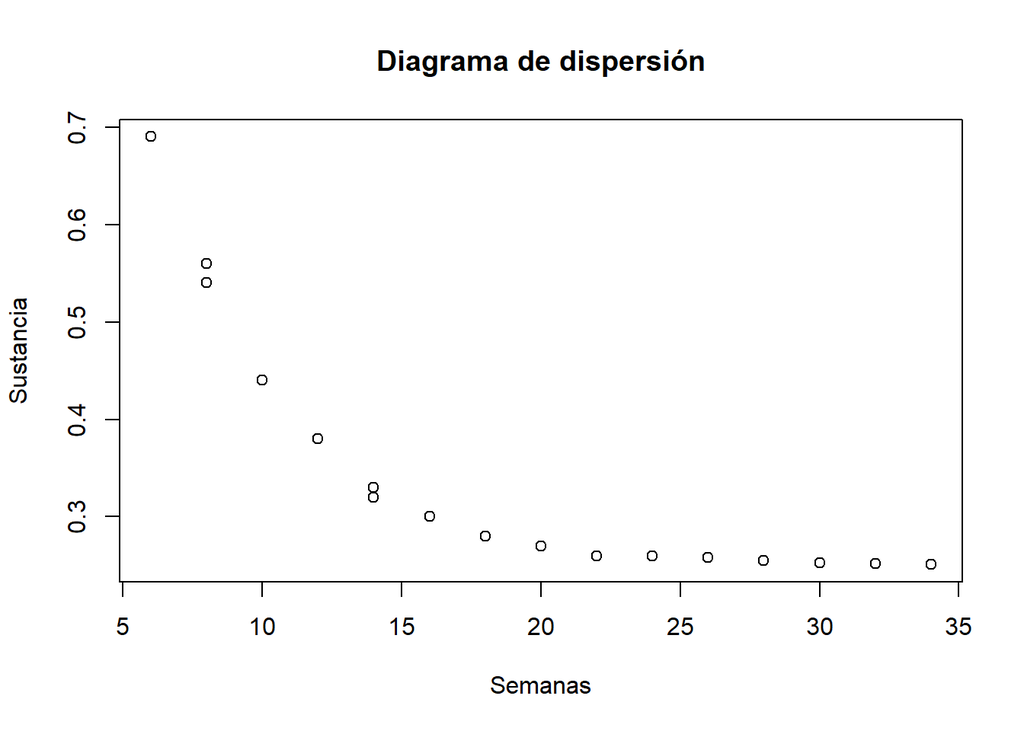

De estos datos, se observa que el dato inicial se da en la semana 6 con una cantidad de sustancia de 0.690, por lo que $\alpha = 0.690$ y $\delta = 6$.

2. Realizar el análisis con los valores de $\alpha$ y $\delta$. ¿El modelo es bueno?

```
## 10.57915    (9.84e+01): par = (-1 -0.1)
## 0.1520633   (1.72e+01): par = (0.3126238 -0.1248141)
## 0.007075515 (3.13e+00): par = (0.2724847 -0.2111446)
## 0.0006579315 (3.58e-02): par = (0.2473595 -0.2059802)
## 0.0006571103 (1.16e-03): par = (0.247416 -0.2065302)
## 0.0006571095 (4.81e-05): par = (0.2474067 -0.2065081)
## 0.0006571095 (2.00e-06): par = (0.2474071 -0.206509)
```

```
##
## Formula: Sustancia ~ expo(Semanas, b, c)
##
## Parameters:
##    Estimate Std. Error t value Pr(>|t|)
## b  0.247407   0.002732   90.56   <2e-16 ***
## c -0.206509   0.004930  -41.89   <2e-16 ***
## ---
## Signif. codes:  0 '***' 0.001 '**' 0.01 '*' 0.05 '.' 0.1 ' ' 1
##
## Residual standard error: 0.006619 on 15 degrees of freedom
##
## Number of iterations to convergence: 6
## Achieved convergence tolerance: 1.999e-06
```

Ambos parámetros son significativos para el modelo.

```
## [1] 0.0006571095
```

Además, el valor de la desviación es muy bajo, por lo que el modelo es bueno.

3. ¿Cuáles son los valores de los coeficientes de regresión?

```
##         b
## 0.2474071
```

```
##         c
## -0.206509
```

Los coeficientes del modelo son $\beta_0 = 0.2474071$ y $\beta_1 = 0.206509$.

4. Predecir el porcentaje de Y para 9 y 15 semanas.

```
## # A tibble: 2 × 2
##   Semanas Porcentaje
##     <dbl>      <dbl>
## 1       9      0.486
## 2      15      0.316
```

Por último, el gráfico del modelo de regresión exponencial queda como sigue:

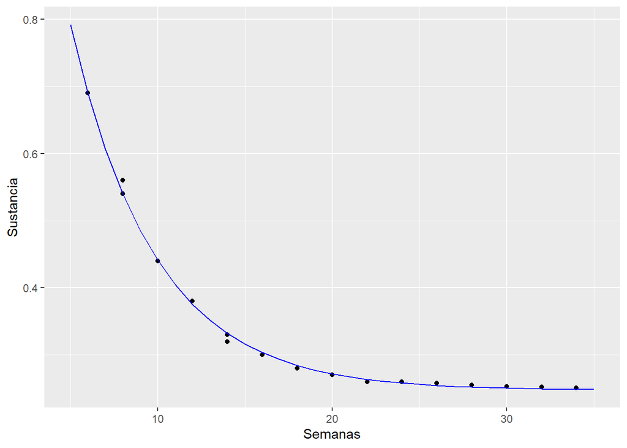

2. Consideremos el data ice-cream que contiene información sobre la temperatura y el número correspondiente de unidades de helados vendidos. Realizar un análisis de regresión polinomial (considerar polinomios de grado 2 hasta el grado 10) para predecir la venta de helados basadas en entradas de temperatura. Hallar la ecuación del mejor modelo polinomial.

El diagrama de dispersión de la base de datos es:

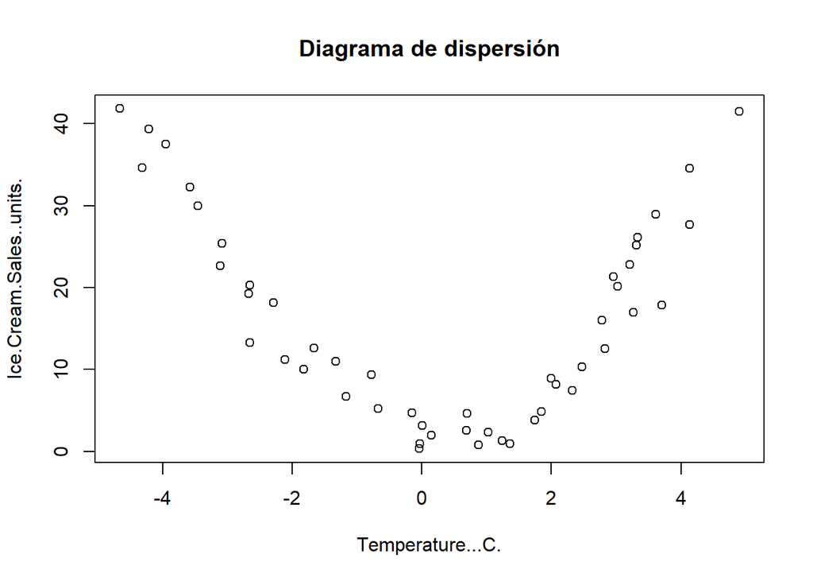

## Modelo 1 (Polinomio cuadrático)

```
##
## Call:
## lm(formula = Ice.Cream.Sales..units. ~ Temperature...C. + I(Temperature...C.^2),
##     data = icecream)
##
## Residuals:
##     Min      1Q  Median      3Q     Max
## -7.1543 -2.7190  0.2208  2.7906  5.5443
##
## Coefficients:
##                       Estimate Std. Error t value Pr(>|t|)
## (Intercept)            2.95177    0.70970   4.159 0.000138 ***
## Temperature...C.      -0.82468    0.17466  -4.722 2.22e-05 ***
## I(Temperature...C.^2)  1.82953    0.07403  24.715  < 2e-16 ***
## ---
## Signif. codes:  0 '***' 0.001 '**' 0.01 '*' 0.05 '.' 0.1 ' ' 1
##
## Residual standard error: 3.264 on 46 degrees of freedom
## Multiple R-squared:  0.9321, Adjusted R-squared:  0.9292
## F-statistic: 315.8 on 2 and 46 DF,  p-value: < 2.2e-16
```

Los coeficientes del modelo son significativos, y el R-cuadrado ajustado es de 0.9292, por lo que este es un buen modelo.

$$Y = 2.95177 - 0.82468X + 1.82953X^2$$
donde $Y$ = Helados vendidos y $X$ = Temperatura.

## Modelo 2 (Polinomio cúbico)

```
##
## Call:
## lm(formula = Ice.Cream.Sales..units. ~ Temperature...C. + I(Temperature...C.^2) +
##     I(Temperature...C.^3), data = icecream)
##
## Residuals:
##     Min      1Q  Median      3Q     Max
## -7.3745 -2.4962 -0.1326  2.3011  5.7732
##
## Coefficients:
##                       Estimate Std. Error t value Pr(>|t|)
## (Intercept)            3.06137    0.69553   4.401 6.54e-05 ***
## Temperature...C.      -1.48090    0.40139  -3.689 0.000604 ***
## I(Temperature...C.^2)  1.82431    0.07233  25.222  < 2e-16 ***
## I(Temperature...C.^3)  0.05141    0.02847   1.806 0.077624 .
## ---
## Signif. codes:  0 '***' 0.001 '**' 0.01 '*' 0.05 '.' 0.1 ' ' 1
##
## Residual standard error: 3.187 on 45 degrees of freedom
## Multiple R-squared:  0.9367, Adjusted R-squared:  0.9325
## F-statistic:   222 on 3 and 45 DF,  p-value: < 2.2e-16
```

Los coeficientes del modelo son significativos, excepto por el coeficiente del término cúbico. Sin embargo, el R-cuadrado ajustado es de 0.9325, por lo que este es un buen modelo. Aun así, se prefiere el modelo 1, ya que es más sencillo y tiene un R-cuadrado ajustado similar.

$$Y = 3.06137 - 1.48090 X + 1.82431 X^2 +
0.05141 X^3$$
donde $Y$ = Helados vendidos y $X$ = Temperatura.

## Modelo 3 (Polinomio de grado cuatro)

```
##
## Call:
## lm(formula = Ice.Cream.Sales..units. ~ Temperature...C. + I(Temperature...C.^2) +
##     I(Temperature...C.^3) + I(Temperature...C.^4), data = icecream)
##
## Residuals:
##     Min      1Q  Median      3Q     Max
## -8.0229 -2.0413  0.1652  2.1342  4.8582
##
## Coefficients:
##                       Estimate Std. Error t value Pr(>|t|)
## (Intercept)            1.95590    0.81070   2.413 0.020073 *
## Temperature...C.      -1.61337    0.38641  -4.175 0.000138 ***
## I(Temperature...C.^2)  2.28685    0.20728  11.033 2.96e-14 ***
## I(Temperature...C.^3)  0.06002    0.02736   2.194 0.033582 *
## I(Temperature...C.^4) -0.02411    0.01019  -2.366 0.022453 *
## ---
## Signif. codes:  0 '***' 0.001 '**' 0.01 '*' 0.05 '.' 0.1 ' ' 1
##
## Residual standard error: 3.036 on 44 degrees of freedom
## Multiple R-squared:  0.9438, Adjusted R-squared:  0.9387
## F-statistic: 184.9 on 4 and 44 DF,  p-value: < 2.2e-16
```

Los coeficientes del modelo son significativos y el R-cuadrado ajustado es de 0.9387, por lo que es un buen modelo. De momento, se preferirá este modelo, ya que tiene un R-cuadrado ajustado mayor que los modelos anteriores.

$$Y = 1.95590 - 1.61337 X + 2.28685 X^2 +
0.06002 X^3 - 0.02411 X^4$$
donde $Y$ = Helados vendidos y $X$ = Temperatura.

## Modelo 4 (Polinomio de grado cinco)

```
##
## Call:
## lm(formula = Ice.Cream.Sales..units. ~ Temperature...C. + I(Temperature...C.^2) +
##     I(Temperature...C.^3) + I(Temperature...C.^4) + I(Temperature...C.^5),
##     data = icecream)
##
## Residuals:
##     Min      1Q  Median      3Q     Max
## -8.5704 -1.8596  0.3919  2.2783  4.4607
##
## Coefficients:
##                        Estimate Std. Error t value Pr(>|t|)
## (Intercept)            2.104848   0.821539   2.562  0.01399 *
## Temperature...C.      -2.226936   0.694280  -3.208  0.00253 **
## I(Temperature...C.^2)  2.225005   0.215000  10.349 3.02e-13 ***
## I(Temperature...C.^3)  0.179544   0.115709   1.552  0.12806
## I(Temperature...C.^4) -0.020737   0.010661  -1.945  0.05831 .
## I(Temperature...C.^5) -0.004575   0.004304  -1.063  0.29371
## ---
## Signif. codes:  0 '***' 0.001 '**' 0.01 '*' 0.05 '.' 0.1 ' ' 1
##
## Residual standard error: 3.031 on 43 degrees of freedom
## Multiple R-squared:  0.9453, Adjusted R-squared:  0.9389
## F-statistic: 148.6 on 5 and 43 DF,  p-value: < 2.2e-16
```

$$Y = 2.104848 - 2.226936 X + 2.225005
X^2 + 0.179544 X^3 - 0.020737 X^4 - 0.004575 X^5$$
donde $Y$ = Helados vendidos y $X$ = Temperatura.

## Modelo 5 (Polinomio de grado seis)

```
##
## Call:
## lm(formula = Ice.Cream.Sales..units. ~ Temperature...C. + I(Temperature...C.^2) +
##     I(Temperature...C.^3) + I(Temperature...C.^4) + I(Temperature...C.^5) +
##     I(Temperature...C.^6), data = icecream)
##
## Residuals:
##     Min      1Q  Median      3Q     Max
## -9.0327 -1.7822  0.4806  1.9979  4.5498
##
## Coefficients:
##                        Estimate Std. Error t value Pr(>|t|)
## (Intercept)            2.519797   0.935057   2.695 0.010084 *
## Temperature...C.      -2.103966   0.707669  -2.973 0.004866 **
## I(Temperature...C.^2)  1.831813   0.472863   3.874 0.000369 ***
## I(Temperature...C.^3)  0.150368   0.120018   1.253 0.217180
## I(Temperature...C.^4)  0.031080   0.056499   0.550 0.585165
## I(Temperature...C.^5) -0.003222   0.004547  -0.709 0.482451
## I(Temperature...C.^6) -0.001637   0.001753  -0.934 0.355664
## ---
## Signif. codes:  0 '***' 0.001 '**' 0.01 '*' 0.05 '.' 0.1 ' ' 1
##
## Residual standard error: 3.036 on 42 degrees of freedom
## Multiple R-squared:  0.9464, Adjusted R-squared:  0.9387
## F-statistic: 123.6 on 6 and 42 DF,  p-value: < 2.2e-16
```

Los cuatro coeficientes de mayor grado no son significativos por lo cual este modelo no es bueno.

## Modelo 6 (Polinomio de grado siete)

```
##
## Call:
## lm(formula = Ice.Cream.Sales..units. ~ Temperature...C. + I(Temperature...C.^2) +
##     I(Temperature...C.^3) + I(Temperature...C.^4) + I(Temperature...C.^5) +
##     I(Temperature...C.^6) + I(Temperature...C.^7), data = icecream)
##
## Residuals:
##     Min      1Q  Median      3Q     Max
## -8.4996 -1.5687  0.4306  1.7297  3.8754
##
## Coefficients:
##                         Estimate Std. Error t value Pr(>|t|)
## (Intercept)            2.7962451  0.9023767   3.099 0.003504 **
## Temperature...C.      -3.7656305  1.0067775  -3.740 0.000563 ***
## I(Temperature...C.^2)  1.6159432  0.4622672   3.496 0.001150 **
## I(Temperature...C.^3)  0.7707511  0.3011054   2.560 0.014259 *
## I(Temperature...C.^4)  0.0620332  0.0557642   1.112 0.272438
## I(Temperature...C.^5) -0.0618640  0.0266717  -2.319 0.025429 *
## I(Temperature...C.^6) -0.0028048  0.0017555  -1.598 0.117790
## I(Temperature...C.^7)  0.0015530  0.0006969   2.228 0.031395 *
## ---
## Signif. codes:  0 '***' 0.001 '**' 0.01 '*' 0.05 '.' 0.1 ' ' 1
##
## Residual standard error: 2.902 on 41 degrees of freedom
## Multiple R-squared:  0.9522, Adjusted R-squared:  0.944
## F-statistic: 116.6 on 7 and 41 DF,  p-value: < 2.2e-16
```

Dos coeficientes no son significativos, a pesar de que el R-cuadrado ajustado es de 0.944, el modelo 3 sigue siendo el mejor.

## Modelo 7 (Polinomio de grado ocho)

```
##
## Call:
## lm(formula = Ice.Cream.Sales..units. ~ Temperature...C. + I(Temperature...C.^2) +
##     I(Temperature...C.^3) + I(Temperature...C.^4) + I(Temperature...C.^5) +
##     I(Temperature...C.^6) + I(Temperature...C.^7) + I(Temperature...C.^8),
##     data = icecream)
##
## Residuals:
##     Min      1Q  Median      3Q     Max
## -8.6144 -1.3306  0.3081  1.6483  4.6595
##
## Coefficients:
##                         Estimate Std. Error t value Pr(>|t|)
## (Intercept)            3.2660000  0.9989485   3.269  0.00222 **
## Temperature...C.      -3.5717538  1.0203297  -3.501  0.00116 **
## I(Temperature...C.^2)  0.8280976  0.8597635   0.963  0.34125
## I(Temperature...C.^3)  0.6940567  0.3086404   2.249  0.03010 *
## I(Temperature...C.^4)  0.2486680  0.1806612   1.376  0.17634
## I(Temperature...C.^5) -0.0540281  0.0275747  -1.959  0.05707 .
## I(Temperature...C.^6) -0.0167554  0.0129665  -1.292  0.20370
## I(Temperature...C.^7)  0.0013142  0.0007293   1.802  0.07909 .
## I(Temperature...C.^8)  0.0003204  0.0002950   1.086  0.28405
## ---
## Signif. codes:  0 '***' 0.001 '**' 0.01 '*' 0.05 '.' 0.1 ' ' 1
##
## Residual standard error: 2.895 on 40 degrees of freedom
## Multiple R-squared:  0.9536, Adjusted R-squared:  0.9443
## F-statistic: 102.7 on 8 and 40 DF,  p-value: < 2.2e-16
```

## Modelo 8 (Polinomio de grado nueve)

```
##
## Call:
## lm(formula = Ice.Cream.Sales..units. ~ Temperature...C. + I(Temperature...C.^2) +
##     I(Temperature...C.^3) + I(Temperature...C.^4) + I(Temperature...C.^5) +
##     I(Temperature...C.^6) + I(Temperature...C.^7) + I(Temperature...C.^8) +
##     I(Temperature...C.^9), data = icecream)
##
## Residuals:
##     Min      1Q  Median      3Q     Max
## -8.2747 -1.6050  0.3022  1.8464  4.1968
##
## Coefficients:
##                         Estimate Std. Error t value Pr(>|t|)
## (Intercept)            3.3418030  1.0098351   3.309  0.00202 **
## Temperature...C.      -4.3461196  1.4649959  -2.967  0.00512 **
## I(Temperature...C.^2)  0.7299332  0.8747576   0.834  0.40912
## I(Temperature...C.^3)  1.1804083  0.7263588   1.625  0.11220
## I(Temperature...C.^4)  0.2743784  0.1849763   1.483  0.14603
## I(Temperature...C.^5) -0.1361112  0.1142496  -1.191  0.24072
## I(Temperature...C.^6) -0.0189313  0.0133672  -1.416  0.16464
## I(Temperature...C.^7)  0.0063872  0.0068890   0.927  0.35954
## I(Temperature...C.^8)  0.0003794  0.0003072   1.235  0.22428
## I(Temperature...C.^9) -0.0001030  0.0001391  -0.741  0.46337
## ---
## Signif. codes:  0 '***' 0.001 '**' 0.01 '*' 0.05 '.' 0.1 ' ' 1
##
## Residual standard error: 2.912 on 39 degrees of freedom
## Multiple R-squared:  0.9542, Adjusted R-squared:  0.9436
## F-statistic: 90.28 on 9 and 39 DF,  p-value: < 2.2e-16
```

Casi todos los coeficientes no son significativos, por lo que este modelo tampoco es bueno.

## Modelo 9 (Polinomio de grado diez)

```
##
## Call:
## lm(formula = Ice.Cream.Sales..units. ~ Temperature...C. + I(Temperature...C.^2) +
##     I(Temperature...C.^3) + I(Temperature...C.^4) + I(Temperature...C.^5) +
##     I(Temperature...C.^6) + I(Temperature...C.^7) + I(Temperature...C.^8) +
##     I(Temperature...C.^9) + I(Temperature...C.^10), data = icecream)
##
## Residuals:
##     Min      1Q  Median      3Q     Max
## -8.9527 -1.5065  0.2709  1.8005  4.6339
##
## Coefficients:
##                          Estimate Std. Error t value Pr(>|t|)
## (Intercept)             2.933e+00  1.105e+00   2.655  0.01153 *
## Temperature...C.       -4.452e+00  1.472e+00  -3.024  0.00446 **
## I(Temperature...C.^2)   1.861e+00  1.508e+00   1.234  0.22467
## I(Temperature...C.^3)   1.238e+00  7.304e-01   1.695  0.09830 .
## I(Temperature...C.^4)  -1.698e-01  5.162e-01  -0.329  0.74395
## I(Temperature...C.^5)  -1.468e-01  1.151e-01  -1.276  0.20977
## I(Temperature...C.^6)   4.085e-02  6.621e-02   0.617  0.54091
## I(Temperature...C.^7)   7.179e-03  6.956e-03   1.032  0.30853
## I(Temperature...C.^8)  -2.845e-03  3.511e-03  -0.810  0.42276
## I(Temperature...C.^9)  -1.236e-04  1.412e-04  -0.876  0.38677
## I(Temperature...C.^10)  5.982e-05  6.488e-05   0.922  0.36235
## ---
## Signif. codes:  0 '***' 0.001 '**' 0.01 '*' 0.05 '.' 0.1 ' ' 1
##
## Residual standard error: 2.917 on 38 degrees of freedom
## Multiple R-squared:  0.9552, Adjusted R-squared:  0.9434
## F-statistic: 81.03 on 10 and 38 DF,  p-value: < 2.2e-16
```

Varios coeficientes no son significativos, por lo que este modelo tampoco es bueno.

Graficando los modelos 1 y 3 junto con el diagrama de dispersión, se obtiene lo siguiente:

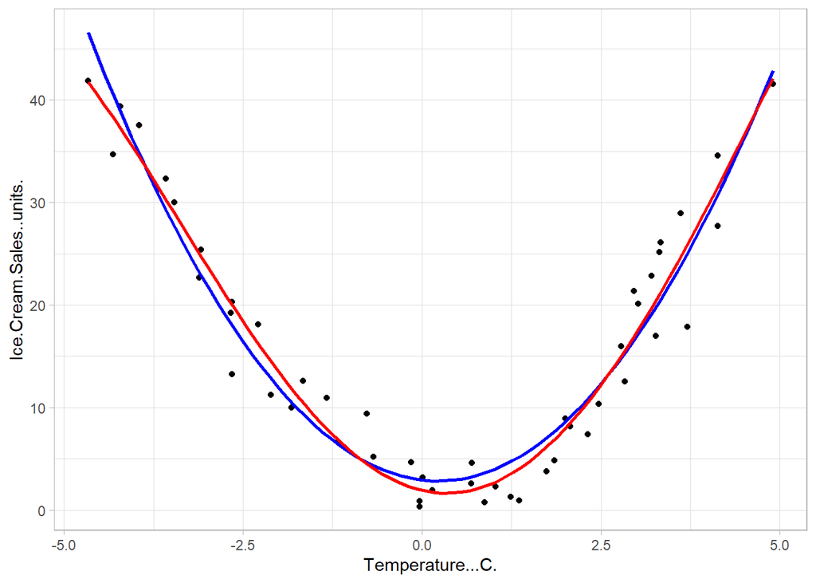

En conclusión, el mejor modelo es el modelo 3 (polinomio de grado cuatro):

$$Y = 1.95590 - 1.61337 X + 2.28685 X^2 +
0.06002 X^3 - 0.02411 X^4$$